# R Notebook

### About 911:

- Created by Congress in 2004 as the 911 Implementation and Coordination Office (ICO), the National 911 Program is housed within the National Highway Traffic Safety Administration at the U.S. Department of Transportation and is a joint program with the National Telecommunication and Information Administration in the Department of Commerce.

For more information : http://www.911.gov/about_national_911program.html

### About Montgomery County

- Montgomery County, locally also referred to as Montco, is a county located in the Commonwealth of Pennsylvania. As of the 2010 census, the population was 799,874, making it the third-most populous county in Pennsylvania, after Philadelphia and Allegheny Counties. The county seat is Norristown. Montgomery County is very diverse, ranging from farms and open land in Upper Hanover to densely populated rowhouse streets in Cheltenham.

### Sneak peak into the dataset

```
[1] 663522      9
'data.frame':   663522 obs. of  9 variables:
 $ lat      : num  40.3 40.3 40.1 40.1 40.3 ...
 $ lng      : num  -75.6 -75.3 -75.4 -75.3 -75.6 ...
 $ desc     : Factor w/ 663282 levels ".  ; AMBLER; 2018-04-05 @ 14:35:42;",..: 467158 67539 251193 14378 102372 87032 312838 117579 342883 62923 ...
 $ zip      : int  19525 19446 19401 19401 NA 19446 19044 19426 19438 19462 ...
 $ title    : Factor w/ 148 levels "EMS: ABDOMINAL PAINS",..: 10 23 104 18 25 42 50 60 69 146 ...
 $ timeStamp: Factor w/ 640754 levels "2015-12-10 14:39:21",..: 10 13 1 6 8 2 5 3 7 16 ...
 $ twp      : Factor w/ 69 levels "","ABINGTON",..: 36 20 37 37 30 23 21 49 32 42 ...
 $ addr     : Factor w/ 41292 levels ".","10TH AVE",..: 29611 3866 15602 948 6189 5155 19440 7168 21124 3479 ...
 $ e        : int  1 1 1 1 1 1 1 1 1 1 ...
      lat             lng
 Min.   : 0.00   Min.   :-119.70
 1st Qu.:40.10   1st Qu.: -75.39
 Median :40.14   Median : -75.31
 Mean   :40.16   Mean   : -75.30
 3rd Qu.:40.23   3rd Qu.: -75.21
 Max.   :51.34   Max.   :  87.85

                                                                              desc
 CITY AVE & CARDINAL AVE;  LOWER MERION; Station 313; 2019-04-30 @ 15:11:01;    :     5
 GERMANTOWN PIKE; WORCESTER; 2017-09-27 @ 17:50:24-Station:STA83;               :     4
 GREEN ST & E BASIN ST;  NORRISTOWN; Station 308A; 2016-05-10 @ 20:23:26;       :     4
 WALDEN POND WAY & WOODVIEW LN; TOWAMENCIN; 2017-09-27 @ 17:54:55-Station:STA76;:     4
 ASTOR ST & W OAK ST;  NORRISTOWN; Station 308A; 2017-09-27 @ 17:44:37;         :     3
 CHELTENHAM AVE & 79TH AVE;  CHELTENHAM; Station 358A; 2019-04-25 @ 01:48:43;   :     3
 (Other)                                                                        :663499
      zip                                title
 Min.   : 1104   Traffic: VEHICLE ACCIDENT -:148372
 1st Qu.:19038   Traffic: DISABLED VEHICLE -: 47909
 Median :19401   Fire: FIRE ALARM           : 38336
 Mean   :19236   EMS: FALL VICTIM           : 34676
 3rd Qu.:19446   EMS: RESPIRATORY EMERGENCY : 34248
 Max.   :77316   EMS: CARDIAC EMERGENCY     : 32332
 NA's   :80199   (Other)                    :327649
               timeStamp                twp
 2018-10-06 19:26:38:     9   LOWER MERION: 55490
 2018-07-09 13:23:16:     8   ABINGTON    : 39947
 2019-01-09 21:01:46:     7   NORRISTOWN  : 37633
 2019-05-31 07:55:24:     7   UPPER MERION: 36010
 2019-11-08 20:52:00:     7   CHELTENHAM  : 30574
 2020-01-12 01:41:13:     7   POTTSTOWN   : 27387
 (Other)            :663477   (Other)     :436481
                                addr              e
 SHANNONDELL DR & SHANNONDELL BLVD:  7285   Min.   :1
 MAIN ST & OLD SUMNEYTOWN PIKE    :  2576   1st Qu.:1
 THE FAIRWAY  & RYDAL RD          :  1986   Median :1
 EAGLEVILLE RD & SUNDERLAND DR    :  1618   Mean   :1
 EVERGREEN RD & W LIGHTCAP RD     :  1591   3rd Qu.:1
 GERMANTOWN PIKE & HANNAH AVE     :  1557   Max.   :1
 (Other)                          :646909
```

- Zip should be a factor
- time stamp should be of type date
- Can remove dummy variable if it is always 1

### Cleaning the dataset

- Changing the zip class
- Removing the dummy variable
- Changing the class of timestamp

### Creating new variables

- Creating type and subtype based on the title column
- Creating the Year and Month from the timestemp column

### Number of calls over the period of time and by type?

| Date | Total |
| --- | --- |
| 2015-12-10 | 50 |
| 2015-12-11 | 377 |
| 2015-12-12 | 365 |
| 2015-12-13 | 370 |
| 2015-12-14 | 424 |
| 2015-12-15 | 433 |

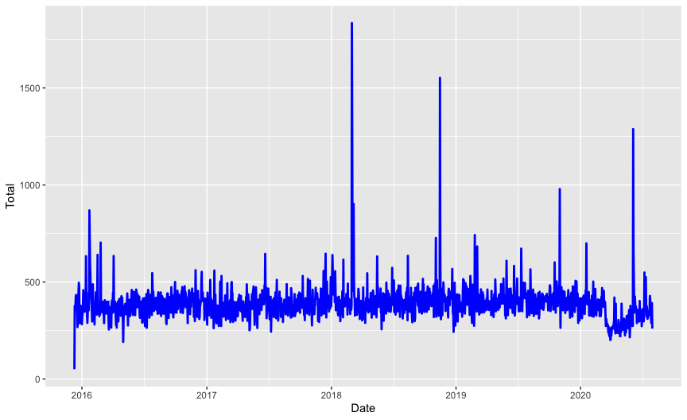

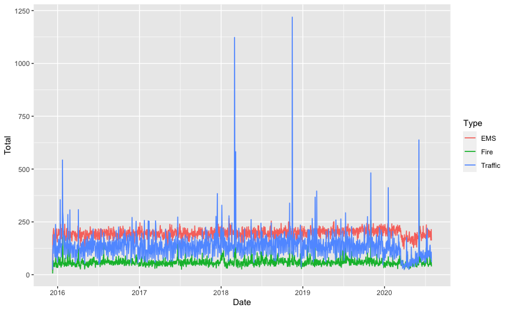

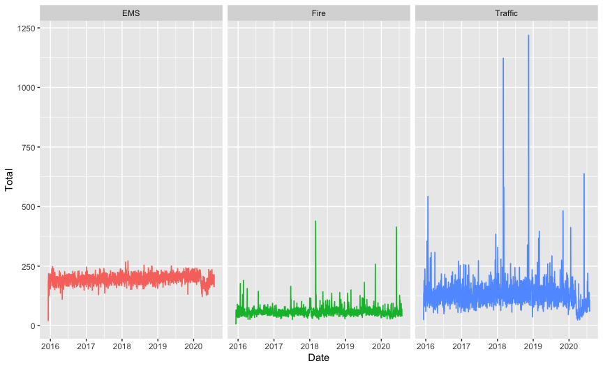

### How many calls hourly, monthly and yearly?

```
  2015   2016   2017   2018   2019   2020
  7916 142360 140343 151527 149118  72258

    1     2     3     4     5     6     7     8     9    10    11
13096 11396 11059 11287 11374 11732 12088 11904 11669 12502 12091
   12
12162

    1     2     3     4     5     6     7     8     9    10    11
13096 11396 11059 11287 11374 11732 12088 11904 11669 12502 12091
   12
12162
```

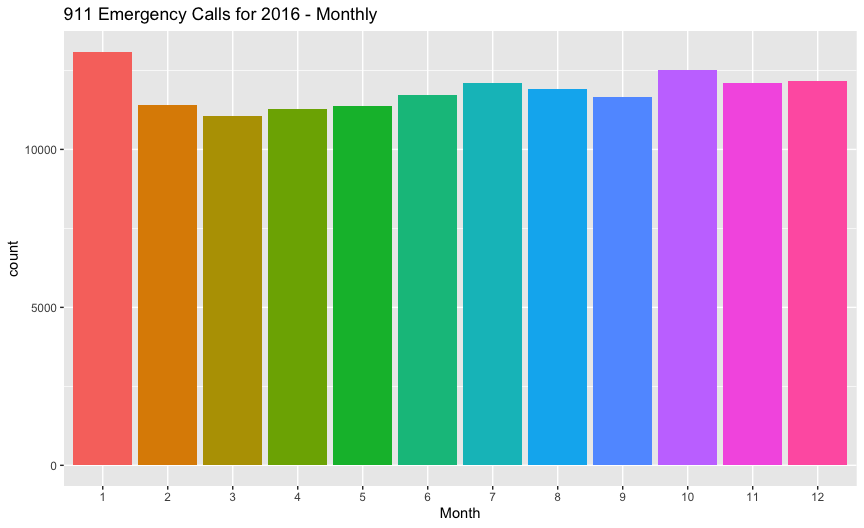

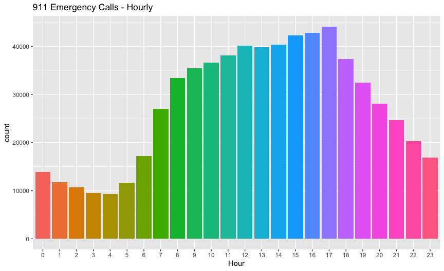

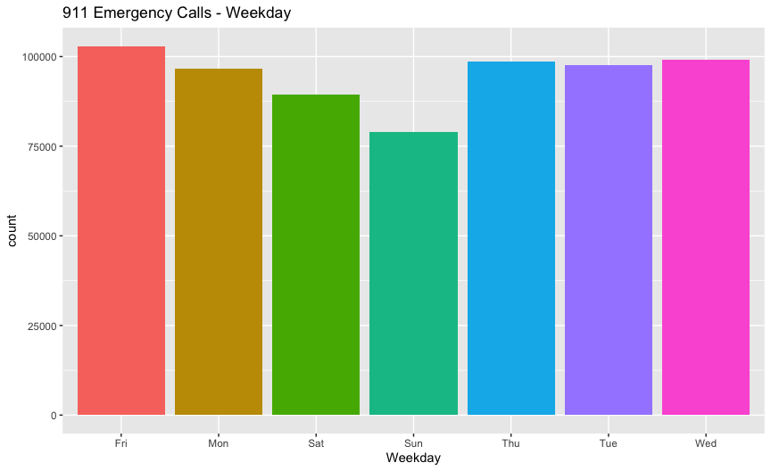

### How many calls based on type?

```
    EMS    Fire Traffic
 332692  100622  230208
```

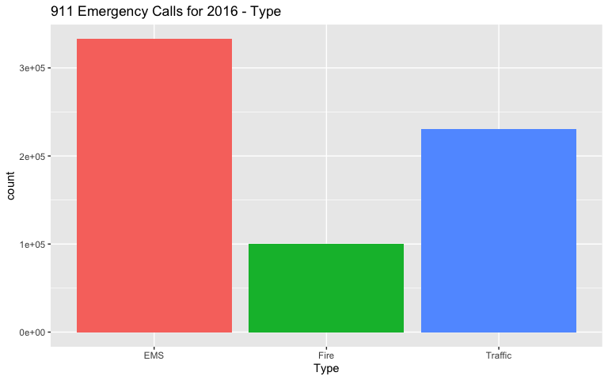

```
      EMS      Fire   Traffic
0.5014031 0.1516483 0.3469486
```

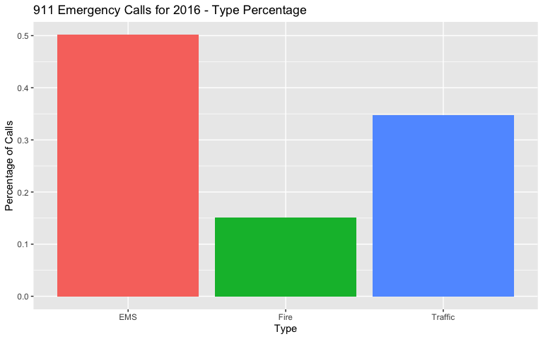

- Nearly 50% of the calls are of Type EMS
- Traffic related come second.

### How many calls from each subtypes in overall dataset and also subtypes within each type?

|  | Var1 | Freq | Perc |
| --- | --- | --- | --- |
| 84 | VEHICLE ACCIDENT | 184749 | 27.843689 |
| 25 | DISABLED VEHICLE | 47917 | 7.221614 |
| 35 | FIRE ALARM | 38452 | 5.795136 |
| 33 | FALL VICTIM | 34683 | 5.227106 |
| 65 | RESPIRATORY EMERGENCY | 34250 | 5.161848 |
| 19 | CARDIAC EMERGENCY | 32339 | 4.873840 |
| 66 | ROAD OBSTRUCTION | 23237 | 3.502069 |
| 72 | SUBJECT IN PAIN | 19650 | 2.961469 |
| 45 | HEAD INJURY | 18304 | 2.758612 |
| 42 | GENERAL WEAKNESS | 11868 | 1.788637 |

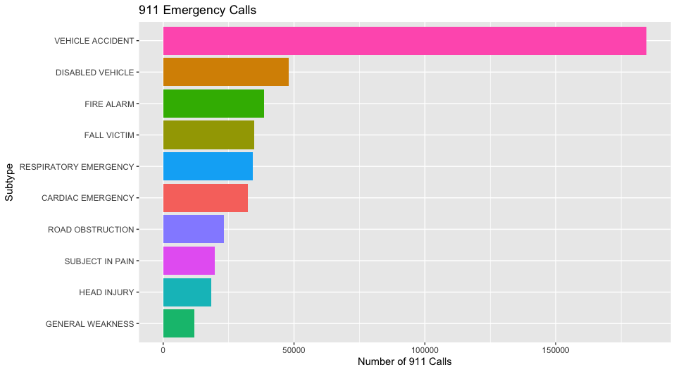

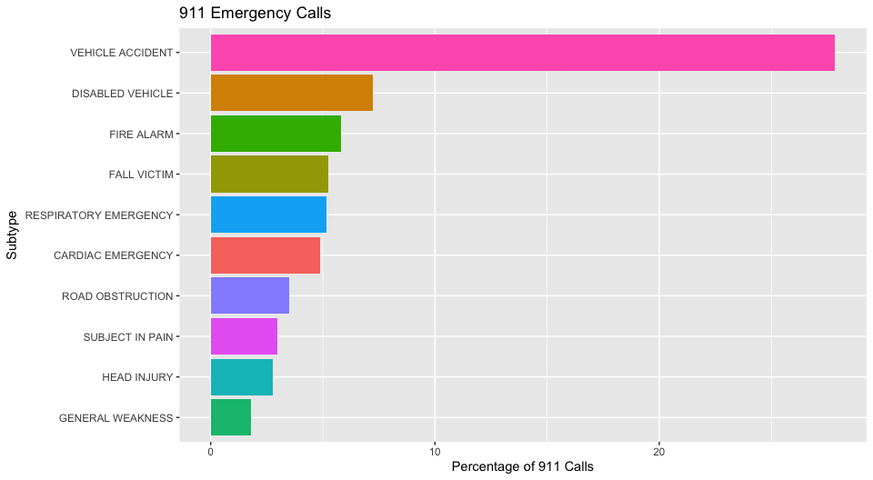

|  | Var1 | Freq | Perc |
| --- | --- | --- | --- |
| 32 | FALL VICTIM | 34676 | 10.422854 |
| 60 | RESPIRATORY EMERGENCY | 34248 | 10.294206 |
| 18 | CARDIAC EMERGENCY | 32332 | 9.718298 |
| 77 | VEHICLE ACCIDENT | 25513 | 7.668654 |
| 66 | SUBJECT IN PAIN | 19646 | 5.905162 |
| 42 | HEAD INJURY | 18301 | 5.500884 |
| 40 | GENERAL WEAKNESS | 11867 | 3.566963 |
| 62 | SEIZURES | 10823 | 3.253159 |
| 69 | SYNCOPAL EPISODE | 10806 | 3.248049 |
| 74 | UNKNOWN MEDICAL EMERGENCY | 10698 | 3.215587 |

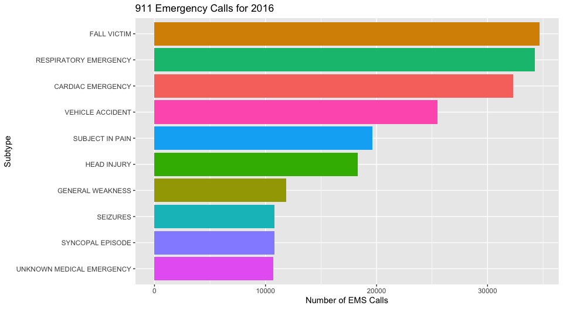

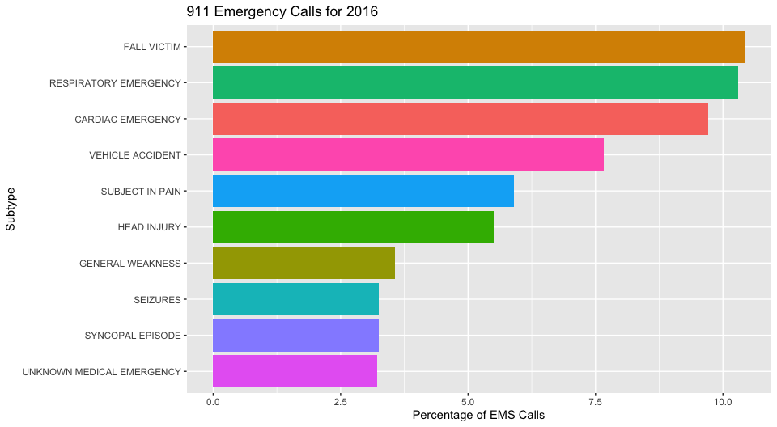

|  | Var1 | Freq | Perc |
| --- | --- | --- | --- |
| 18 | FIRE ALARM | 38336 | 38.099024 |
| 57 | VEHICLE ACCIDENT | 10864 | 10.796844 |
| 19 | FIRE INVESTIGATION | 9444 | 9.385621 |
| 23 | GAS-ODOR/LEAK | 6740 | 6.698336 |
| 14 | ELECTRICAL FIRE OUTSIDE | 5111 | 5.079406 |
| 4 | BUILDING FIRE | 4754 | 4.724613 |
| 21 | FIRE SPECIAL SERVICE | 4050 | 4.024965 |
| 6 | CARBON MONOXIDE DETECTOR | 3990 | 3.965336 |
| 58 | VEHICLE FIRE | 3232 | 3.212021 |
| 60 | WOODS/FIELD FIRE | 2486 | 2.470633 |

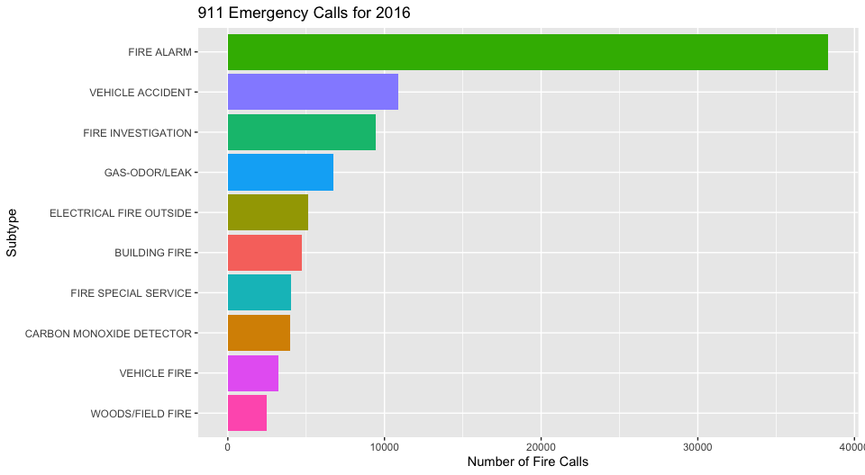

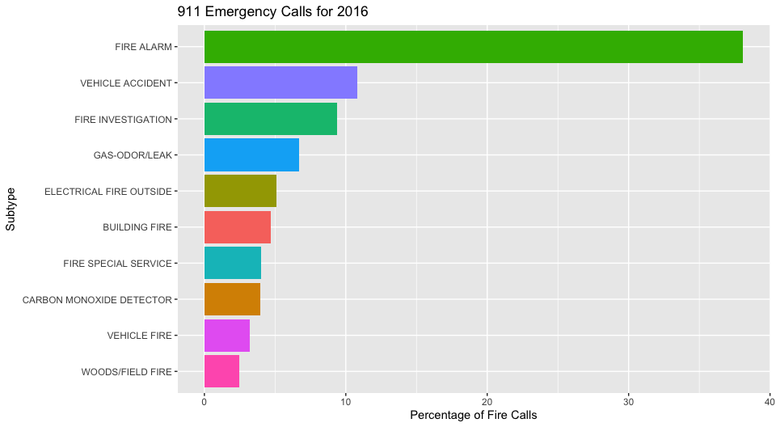

|  | Var1 | Freq | Perc |
| --- | --- | --- | --- |
| 5 | VEHICLE ACCIDENT | 148372 | 64.45127884 |
| 2 | DISABLED VEHICLE | 47909 | 20.81117946 |
| 4 | ROAD OBSTRUCTION | 23235 | 10.09304629 |
| 3 | HAZARDOUS ROAD CONDITIONS | 6833 | 2.96818529 |
| 6 | VEHICLE FIRE | 3366 | 1.46215596 |
| 7 | VEHICLE LEAKING FUEL | 292 | 0.12684181 |
| 1 | DEBRIS/FLUIDS ON HIGHWAY | 201 | 0.08731234 |

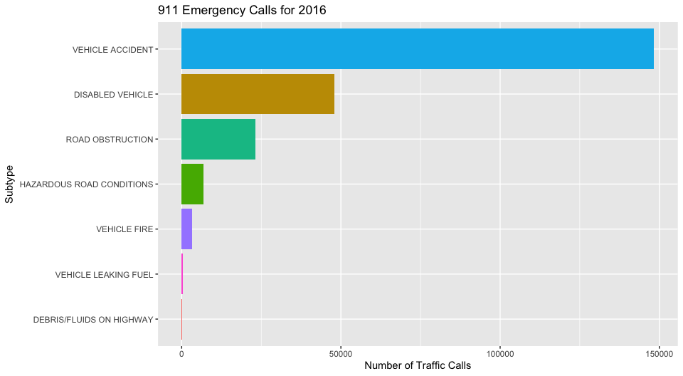

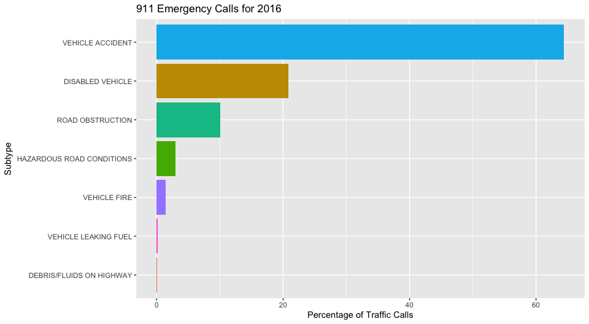

### Which zip codes have the highest number of calls?

|  | Zip | Total | Perc |
| --- | --- | --- | --- |
| 149 | 19401 | 45606 | 7.818310 |
| 174 | 19464 | 43910 | 7.527562 |
| 150 | 19403 | 34888 | 5.980906 |
| 166 | 19446 | 32270 | 5.532098 |
| 153 | 19406 | 22464 | 3.851040 |
| 65 | 19002 | 21070 | 3.612064 |
| 176 | 19468 | 18939 | 3.246743 |
| 88 | 19046 | 17886 | 3.066226 |
| 169 | 19454 | 17661 | 3.027654 |
| 105 | 19090 | 17377 | 2.978967 |

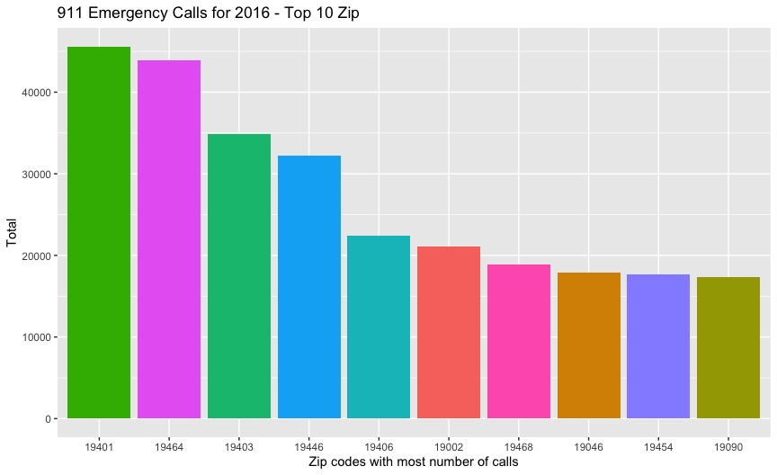

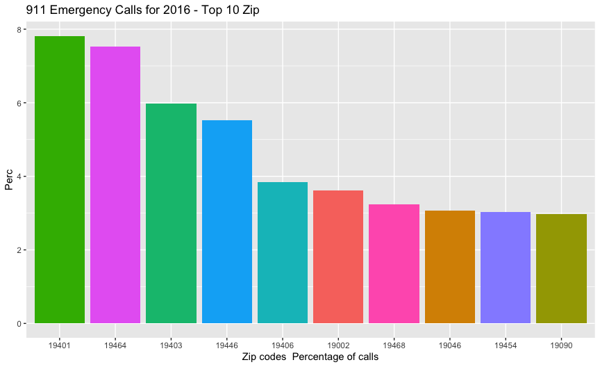

### Which township contributes to majority of the calls?

```
[1] 69
```

|  | Twp | Total | Perc |
| --- | --- | --- | --- |
| 28 | LOWER MERION | 55490 | 8.362948 |
| 2 | ABINGTON | 39947 | 6.020448 |
| 37 | NORRISTOWN | 37633 | 5.671703 |
| 59 | UPPER MERION | 36010 | 5.427100 |
| 8 | CHELTENHAM | 30574 | 4.607835 |
| 43 | POTTSTOWN | 27387 | 4.127520 |
| 60 | UPPER MORELAND | 22932 | 3.456102 |
| 31 | LOWER PROVIDENCE | 22476 | 3.387378 |
| 42 | PLYMOUTH | 20116 | 3.031701 |
| 55 | UPPER DUBLIN | 18862 | 2.842709 |

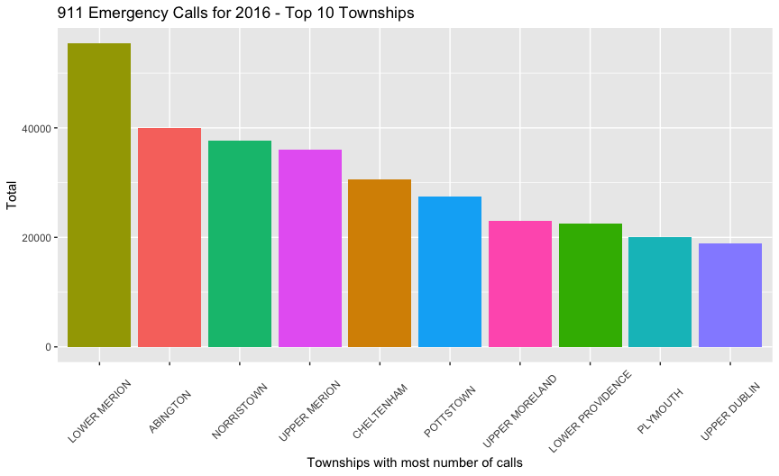

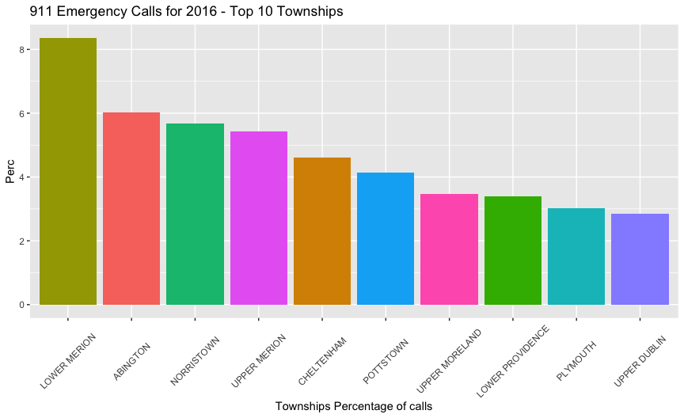

### HeatMaps

- Generating heatmaps of calls by Month, day and hour.

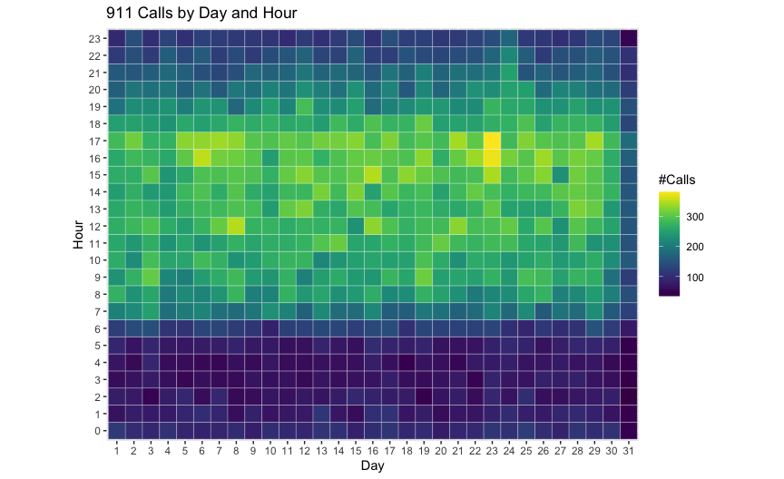

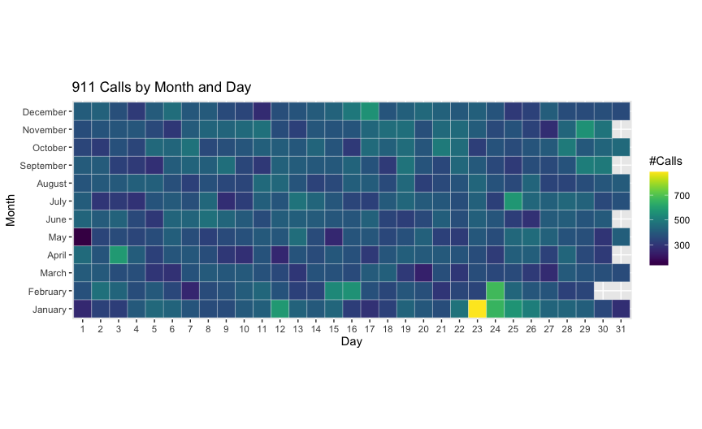

- Majority of the calls are during the day time.
- There are days when the calls were huge in number specially Jan 23.
- When you look closer at what hour of Jan 23 you find that around 4 and 5 in the evening there were huge number of calls.

### How does the type vary among top 10 township?

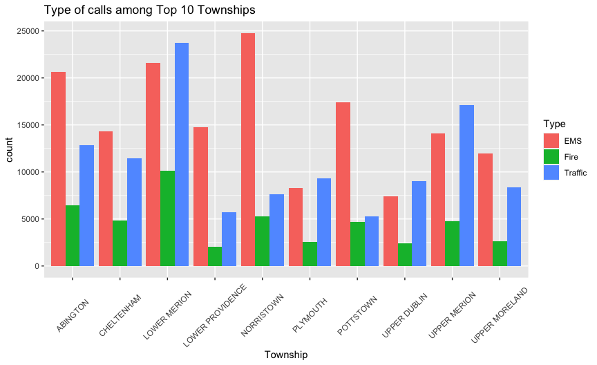

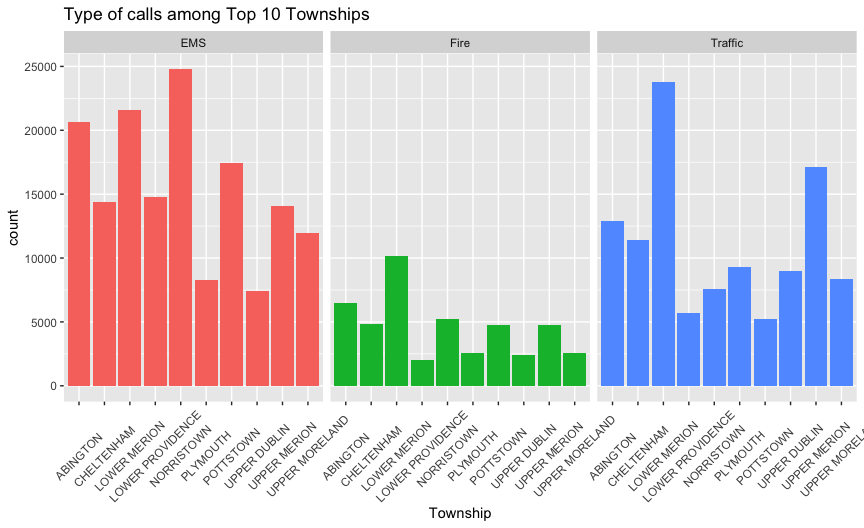

- Lower and Upper Merion have highest number of Traffic calls
- Norristown has highest number of EMS calls
- Lower Merion also has highest number of Fire calls.
- Is there a infrastructure problem in Lower and Upper Merion? Or Is the traffic calls due to reckless driving by large number of people in those areas?

### How does the Top 5 subtypes vary among top 10 twp?

```
[1] 159836     14
```

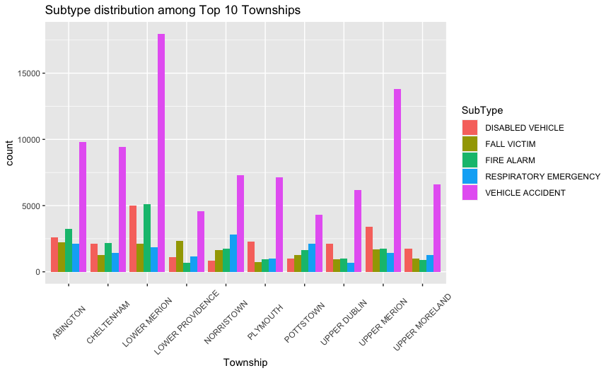

- Vehicle accidents are huge among all the townships which is very concerning given the number of lives at risk during each accident

### Vehicle accidents by hour, day and type

```
    EMS    Fire Traffic
  25513   10864  148372
```

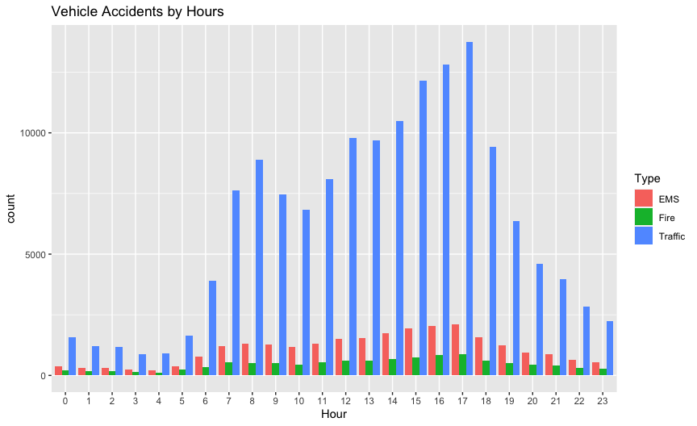

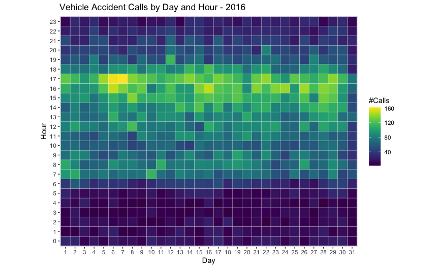

- Majority of the Vehicle Accident calls are during the evening peak hours.
- People should be educated about the rush hour accidents and make them drive with more caution

### CARDIAC EMERGENCY by hour and day

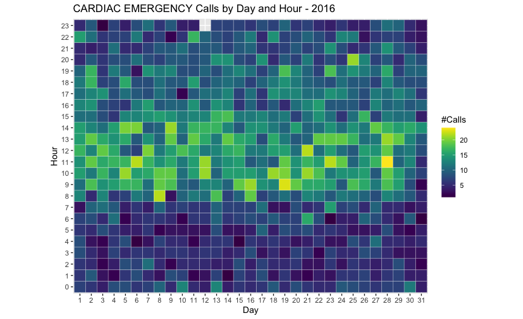

- Majority of the Cardiac emergencies are during day time mostly middle part of the day.
- Is it because people are more stressed out during day time?